# 一，matplotlib API入门

```python
import numpy as np
```

```python
import pandas as pd
```

```python
import matplotlib.pyplot as plt
```

## 1，Figure和Subplot

matplotlib的图像都位于Figure对象中

```python
fig=plt.figure()
```

```python
ax1=fig.add_subplot(2,2,1)
```

```python
ax2=fig.add_subplot(2,2,2)
```

```python
ax3=fig.add_subplot(2,2,3)
```

```python
from numpy.random import randn
```

```python
 plt.plot(randn(50).cumsum(),'k--') #"k--"是一个线型选项，用于告诉matplotlib绘制黑色虚线图
```

```python
_=ax1.hist(randn(100),bins=20,color='k',alpha=0.3)
```

```python
ax2.scatter(np.arange(30),np.arange(30)+3*randn(30))
```

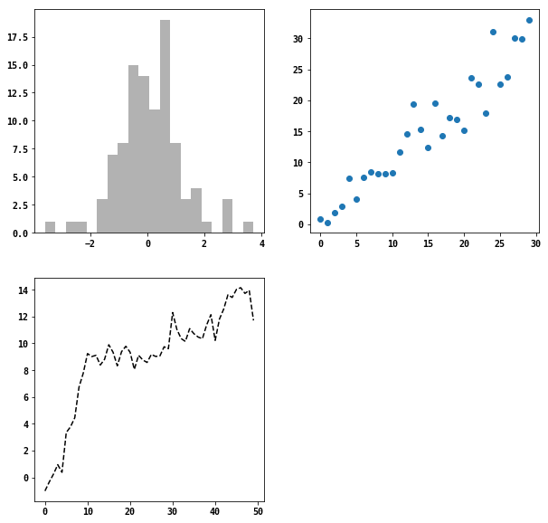

```python
plt.show()
```

```python
fig,axes=plt.subplots(2,3)
```

```python
axes
```

[output not shown]

[figure not shown]

## 2，调整subplot周围的间距

```python
# fig.subplots_adjust(left=None,bottom=None,right=None,top=None,wspace=None,hspace=None)
```

```python
fig,axes=plt.subplots(2,2,sharex=True,sharey=True)
```

```python
for i in range(2):
    for j in range(2):
        axes[i,j].hist(randn(500),bins=50,color='k',alpha=0.5)
```

```python
plt.subplots_adjust(wspace=0,hspace=0)
```

[figure not shown]

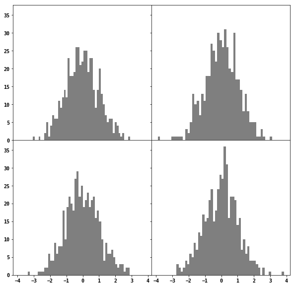

```python
plt.show()
```

## 3，颜色、标记和线型

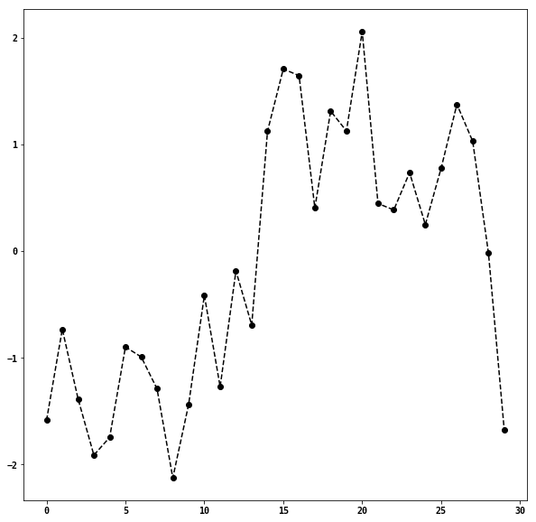

```python
plt.plot(randn(30).cumsum(),'ko--')
plt.show()
```

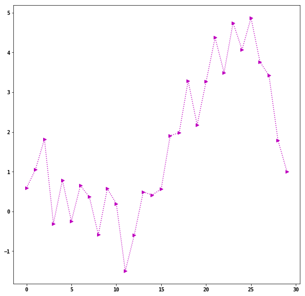

```python
plt.plot(randn(30).cumsum(),color='m',linestyle=':',marker='>')
plt.show()
```

[figure not shown]

```python
data=randn(30).cumsum()
```

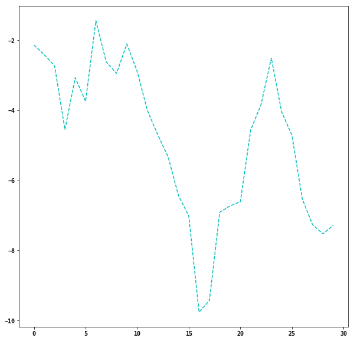

```python
plt.plot(data,'c--',label='Default')
plt.show()
```

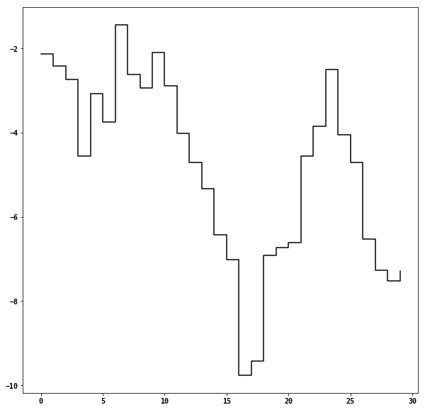

```python
plt.plot(data,'k-',drawstyle='steps-post',label='steps-post')
plt.show()
```

## 4，刻度，标签和图例

大多数图表装饰项，实现方式：1，使用过程型的pyplot接口；2，面向对象的原生matplotlib API

pyplot接口含有诸多方法，使用方式有：

- 调用时不带参数，则返回当前参数值。
- 调用时带参数，则设置参数值。

### 设置标题、轴标签、刻度以及刻度标签

```python
fig=plt.figure()
```

```python
ax=fig.add_subplot(1,1,1)
```

```python
ax.plot(randn(1000).cumsum())
```

set_xticks将刻度放置在数据范围的哪些位置。set_xticklabels是前者值得刻度标签。set_xlabel设置X轴名字。对于Y轴，将前面的x改为y。set_title设置表格名称

```python
ticks=ax.set_xticks([0,250,500,750,1000])
```

```python
labels=ax.set_xticklabels(['one','two','three','four','five'],rotation=30,fontsize='small')
```

```python
ax.set_title('My first matplotlib plot')
```

```python
ax.set_xlabel('Stages')
```

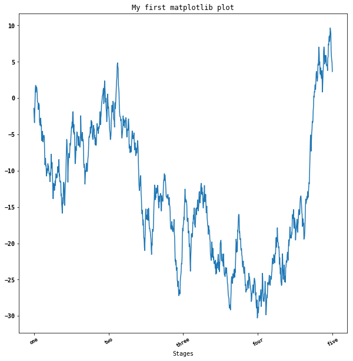

```python
plt.show()
```

### 添加图例

图例（legend）是另一种用于标识图表元素的重要工具

```python
fig=plt.figure()
```

```python
ax=fig.add_subplot(1,1,1)
```

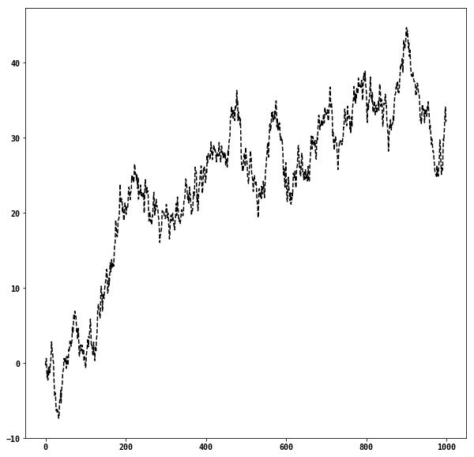

```python
ax.plot(randn(1000).cumsum(),'k--',label='one')
plt.show()
```

```python
ax.plot(randn(1000).cumsum(),'k-',label='two')
plt.show()
```

```python
ax.plot(randn(1000).cumsum(),'m.',label='three')
plt.show()
```

```python
ax.legend(loc='best')
```

## 5，注解以及在Subplot上绘图

```python
from datetime import datetime
```

```python
fig=plt.figure()
```

```python
ax=fig.add_subplot(1,1,1)
```

```python
data=pd.read_csv('D:/PythonDataAnalysis/ch08/spx.csv',index_col=0,parse_dates=True)
```

```python
data
```

|  | SPX |
| --- | --- |
| 1990-02-01 | 328.79 |
| 1990-02-02 | 330.92 |
| 1990-02-05 | 331.85 |
| 1990-02-06 | 329.66 |
| 1990-02-07 | 333.75 |
| 1990-02-08 | 332.96 |
| 1990-02-09 | 333.62 |
| 1990-02-12 | 330.08 |
| 1990-02-13 | 331.02 |
| 1990-02-14 | 332.01 |
| 1990-02-15 | 334.89 |
| 1990-02-16 | 332.72 |
| 1990-02-20 | 327.99 |
| 1990-02-21 | 327.67 |
| 1990-02-22 | 325.70 |
| 1990-02-23 | 324.15 |
| 1990-02-26 | 328.67 |
| 1990-02-27 | 330.26 |
| 1990-02-28 | 331.89 |
| 1990-03-01 | 332.74 |
| 1990-03-02 | 335.54 |
| 1990-03-05 | 333.74 |
| 1990-03-06 | 337.93 |
| 1990-03-07 | 336.95 |
| 1990-03-08 | 340.27 |
| 1990-03-09 | 337.93 |
| 1990-03-12 | 338.67 |
| 1990-03-13 | 336.00 |
| 1990-03-14 | 336.87 |
| 1990-03-15 | 338.07 |
| ... | ... |
| 2011-09-02 | 1173.97 |
| 2011-09-06 | 1165.24 |
| 2011-09-07 | 1198.62 |
| 2011-09-08 | 1185.90 |
| 2011-09-09 | 1154.23 |
| 2011-09-12 | 1162.27 |
| 2011-09-13 | 1172.87 |
| 2011-09-14 | 1188.68 |
| 2011-09-15 | 1209.11 |
| 2011-09-16 | 1216.01 |
| 2011-09-19 | 1204.09 |
| 2011-09-20 | 1202.09 |
| 2011-09-21 | 1166.76 |
| 2011-09-22 | 1129.56 |
| 2011-09-23 | 1136.43 |
| 2011-09-26 | 1162.95 |
| 2011-09-27 | 1175.38 |
| 2011-09-28 | 1151.06 |
| 2011-09-29 | 1160.40 |
| 2011-09-30 | 1131.42 |
| 2011-10-03 | 1099.23 |
| 2011-10-04 | 1123.95 |
| 2011-10-05 | 1144.03 |
| 2011-10-06 | 1164.97 |
| 2011-10-07 | 1155.46 |
| 2011-10-10 | 1194.89 |
| 2011-10-11 | 1195.54 |
| 2011-10-12 | 1207.25 |
| 2011-10-13 | 1203.66 |
| 2011-10-14 | 1224.58 |

5472 rows × 1 columns

```python
spx=data['SPX']
```

```python
spx.plot(ax=ax,style='k-')
```

```python
crisis_data=[
    (datetime(2007,10,11),'Peak of bull market'),
    (datetime(2008,3,12),'Bear Stearns Fails'),
    (datetime(2008,9,15),'Lehman Bankruptcy')
]
```

```python
for date,label in crisis_data:
    ax.annotate(label,xy=(date,spx.asof(date)+50),
                xytext=(date,spx.asof(date)+200),
                arrowprops=dict(facecolor='black'),
                horizontalalignment='left',
                verticalalignment='top')
```

```python
ax.set_xlim(['1/1/2007','1/1/2001'])
```

```
(732677.0, 730486.0)
```

```python
ax.set_ylim([600,1800])
```

```
(600, 1800)
```

```python
ax.set_title('Important date in 2008-2009 financial crisis')
```

**绘制图形（patch）**

```python
fig=plt.figure()
```

```python
ax=fig.add_subplot(1,1,1)
```

```python
rect=plt.Rectangle((0.2,0.75),0.4,0.15,color='k',alpha=0.3)
```

```python
circ=plt.Circle((0.7,0.2),0.15,color='b',alpha=0.3)
```

```python
pgon=plt.Polygon([[0.15,0.15],[0.35,0.4],[0.2,0.6]],color='g',alpha=0.5)
```

```python
ax.add_patch(rect)
```

```python
ax.add_patch(circ)
```

```python
ax.add_patch(pgon)
```

[output not shown]

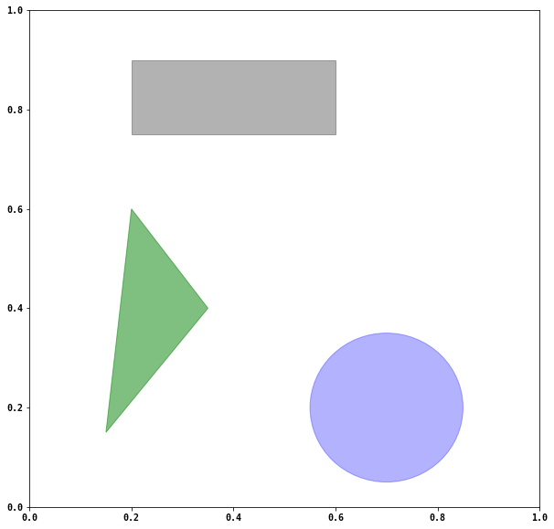

```python
plt.show()
```

## 5，将图表保存到文件

plt.savefig可以将当前图表保存到文件。该方法相当于Figure对象的实例方法savefig

```python
plt.savefig('figpath.svg')
```

图片有两个重要选项：dpi（控制“每英寸点数”分辨率）和bbox_inches(可以剪除当前图表周围的空白部分）

```python
plt.savefig('figpath.png',dpi=400,bbox_inches='tight')
```

savefig不仅可以写入磁盘，也可以写入任何文件类型的对象，比如（StringIO）

```python
from io import StringIO
```

```python
buffer=StringIO()
```

```python
# plt.savefig(buffer)
```

```python
plot_data=buffer.getvalue()
```

[figure not shown]

## 6，matplotlib配置

操作matplotlib配置系统的方式主要有两种。第一种是Python编程方式，即利用rc方法。比如将全局的图像默认大小设置为10*10

```python
plt.rc('figure',figsize=(10,10))
```

rc第一个参数是希望自定义的对象，如‘figure’、‘axes’、‘xtick’、‘ytick’、‘grid’、‘legend’等

```python
font_options={'family':'monospace',
              'weight':'bold',
              'size':'big'}
```

```python
# plt.rc('font',**font_options)
```

# 二，pandas中的绘图函数

## 1，线型图

```python
from pandas import Series,DataFrame
```

```python
s=Series(np.random.randn(10).cumsum(),index=np.arange(0,100,10))
```

```python
s
```

```
0    -0.853546
10   -2.646120
20   -3.012232
30   -3.238681
40   -3.307963
50   -1.680790
60   -1.955642
70   -1.420288
80   -1.699651
90   -2.481779
dtype: float64
```

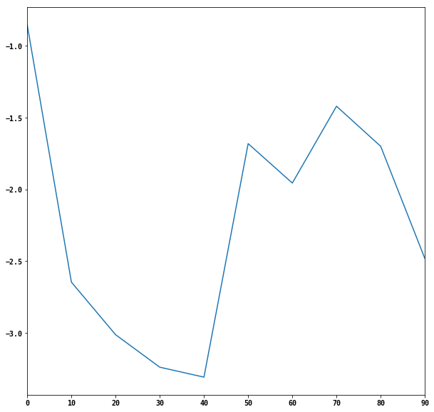

```python
s.plot()
plt.show()
```

```python
df=DataFrame(np.random.randn(10,4).cumsum(0),
             columns=['A','B','C','D'],
             index=np.arange(0,100,10))
```

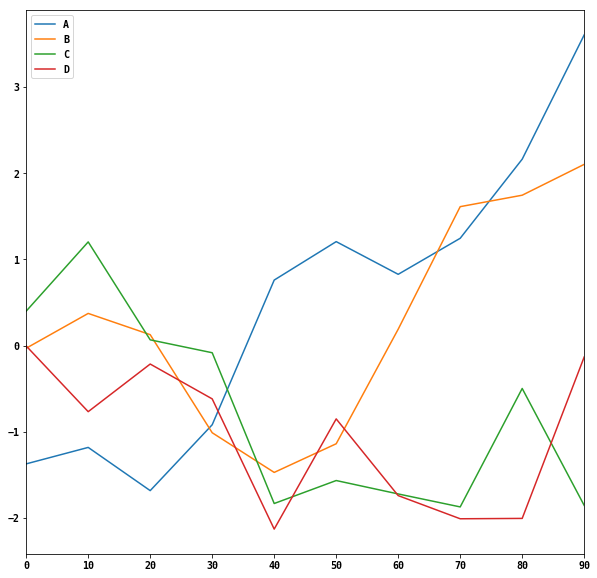

```python
df.plot()
plt.show()
```

[figure not shown]

## 2，柱状图

在代码中加上kind='bar',(垂直柱状图）或kind='barh'(水平柱状图）即可生成柱状图

```python
fig,axes=plt.subplots(2,1)
```

```python
data=Series(np.random.rand(16),index=list('abcdefghigklmnop'))
```

```python
data
```

```
a    0.319543
b    0.287420
c    0.773468
d    0.162628
e    0.405273
f    0.272554
g    0.970243
h    0.909146
i    0.631025
g    0.344034
k    0.728119
l    0.589774
m    0.164152
n    0.283902
o    0.295857
p    0.412098
dtype: float64
```

```python
data.plot(kind='bar',ax=axes[0],color='g',alpha=0.7)
```

```python
data.plot(kind='barh',ax=axes[1],color='k',alpha=0.7)
```

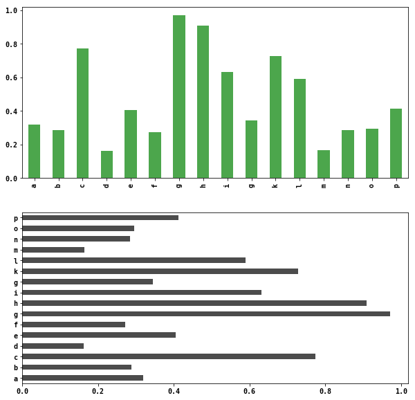

```python
plt.show()
```

```python
df=DataFrame(np.random.rand(6,4),
             index=['one','two','three','four','five','six'],
             columns=pd.Index(['A','B','C','D'],name='Genus'))
```

```python
df
```

| Genus | A | B | C | D |
| --- | --- | --- | --- | --- |
| one | 0.275648 | 0.323160 | 0.245403 | 0.006666 |
| two | 0.202832 | 0.201492 | 0.915768 | 0.514529 |
| three | 0.011138 | 0.222988 | 0.469918 | 0.463406 |
| four | 0.682067 | 0.809002 | 0.070044 | 0.046967 |
| five | 0.754863 | 0.361830 | 0.116056 | 0.490078 |
| six | 0.838532 | 0.646858 | 0.695947 | 0.533981 |

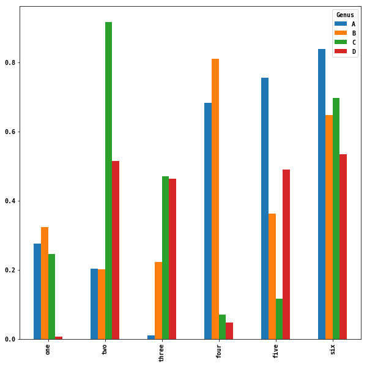

```python
df.plot(kind='bar')
plt.show()
```

设置stacked=True即可为DataFrame生成堆积柱状图

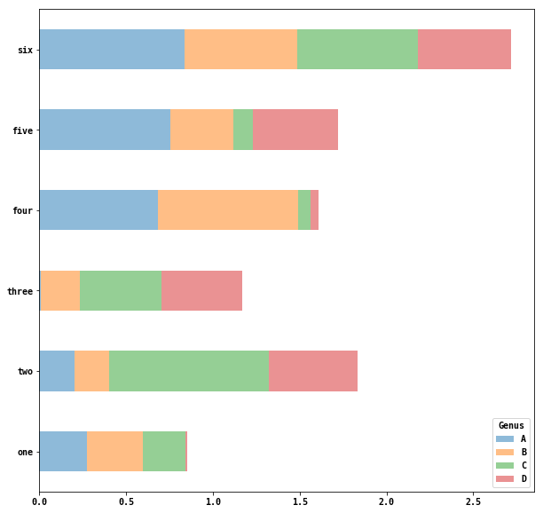

```python
df.plot(kind='barh',stacked=True,alpha=0.5)
plt.show()
```

```python
tips=pd.read_csv('D:/PythonDataAnalysis/ch08/tips.csv')
```

```python
tips
```

|  | total_bill | tip | sex | smoker | day | time | size |
| --- | --- | --- | --- | --- | --- | --- | --- |
| 0 | 16.99 | 1.01 | Female | No | Sun | Dinner | 2 |
| 1 | 10.34 | 1.66 | Male | No | Sun | Dinner | 3 |
| 2 | 21.01 | 3.50 | Male | No | Sun | Dinner | 3 |
| 3 | 23.68 | 3.31 | Male | No | Sun | Dinner | 2 |
| 4 | 24.59 | 3.61 | Female | No | Sun | Dinner | 4 |
| 5 | 25.29 | 4.71 | Male | No | Sun | Dinner | 4 |
| 6 | 8.77 | 2.00 | Male | No | Sun | Dinner | 2 |
| 7 | 26.88 | 3.12 | Male | No | Sun | Dinner | 4 |
| 8 | 15.04 | 1.96 | Male | No | Sun | Dinner | 2 |
| 9 | 14.78 | 3.23 | Male | No | Sun | Dinner | 2 |
| 10 | 10.27 | 1.71 | Male | No | Sun | Dinner | 2 |
| 11 | 35.26 | 5.00 | Female | No | Sun | Dinner | 4 |
| 12 | 15.42 | 1.57 | Male | No | Sun | Dinner | 2 |
| 13 | 18.43 | 3.00 | Male | No | Sun | Dinner | 4 |
| 14 | 14.83 | 3.02 | Female | No | Sun | Dinner | 2 |
| 15 | 21.58 | 3.92 | Male | No | Sun | Dinner | 2 |
| 16 | 10.33 | 1.67 | Female | No | Sun | Dinner | 3 |
| 17 | 16.29 | 3.71 | Male | No | Sun | Dinner | 3 |
| 18 | 16.97 | 3.50 | Female | No | Sun | Dinner | 3 |
| 19 | 20.65 | 3.35 | Male | No | Sat | Dinner | 3 |
| 20 | 17.92 | 4.08 | Male | No | Sat | Dinner | 2 |
| 21 | 20.29 | 2.75 | Female | No | Sat | Dinner | 2 |
| 22 | 15.77 | 2.23 | Female | No | Sat | Dinner | 2 |
| 23 | 39.42 | 7.58 | Male | No | Sat | Dinner | 4 |
| 24 | 19.82 | 3.18 | Male | No | Sat | Dinner | 2 |
| 25 | 17.81 | 2.34 | Male | No | Sat | Dinner | 4 |
| 26 | 13.37 | 2.00 | Male | No | Sat | Dinner | 2 |
| 27 | 12.69 | 2.00 | Male | No | Sat | Dinner | 2 |
| 28 | 21.70 | 4.30 | Male | No | Sat | Dinner | 2 |
| 29 | 19.65 | 3.00 | Female | No | Sat | Dinner | 2 |
| ... | ... | ... | ... | ... | ... | ... | ... |
| 214 | 28.17 | 6.50 | Female | Yes | Sat | Dinner | 3 |
| 215 | 12.90 | 1.10 | Female | Yes | Sat | Dinner | 2 |
| 216 | 28.15 | 3.00 | Male | Yes | Sat | Dinner | 5 |
| 217 | 11.59 | 1.50 | Male | Yes | Sat | Dinner | 2 |
| 218 | 7.74 | 1.44 | Male | Yes | Sat | Dinner | 2 |
| 219 | 30.14 | 3.09 | Female | Yes | Sat | Dinner | 4 |
| 220 | 12.16 | 2.20 | Male | Yes | Fri | Lunch | 2 |
| 221 | 13.42 | 3.48 | Female | Yes | Fri | Lunch | 2 |
| 222 | 8.58 | 1.92 | Male | Yes | Fri | Lunch | 1 |
| 223 | 15.98 | 3.00 | Female | No | Fri | Lunch | 3 |
| 224 | 13.42 | 1.58 | Male | Yes | Fri | Lunch | 2 |
| 225 | 16.27 | 2.50 | Female | Yes | Fri | Lunch | 2 |
| 226 | 10.09 | 2.00 | Female | Yes | Fri | Lunch | 2 |
| 227 | 20.45 | 3.00 | Male | No | Sat | Dinner | 4 |
| 228 | 13.28 | 2.72 | Male | No | Sat | Dinner | 2 |
| 229 | 22.12 | 2.88 | Female | Yes | Sat | Dinner | 2 |
| 230 | 24.01 | 2.00 | Male | Yes | Sat | Dinner | 4 |
| 231 | 15.69 | 3.00 | Male | Yes | Sat | Dinner | 3 |
| 232 | 11.61 | 3.39 | Male | No | Sat | Dinner | 2 |
| 233 | 10.77 | 1.47 | Male | No | Sat | Dinner | 2 |
| 234 | 15.53 | 3.00 | Male | Yes | Sat | Dinner | 2 |
| 235 | 10.07 | 1.25 | Male | No | Sat | Dinner | 2 |
| 236 | 12.60 | 1.00 | Male | Yes | Sat | Dinner | 2 |
| 237 | 32.83 | 1.17 | Male | Yes | Sat | Dinner | 2 |
| 238 | 35.83 | 4.67 | Female | No | Sat | Dinner | 3 |
| 239 | 29.03 | 5.92 | Male | No | Sat | Dinner | 3 |
| 240 | 27.18 | 2.00 | Female | Yes | Sat | Dinner | 2 |
| 241 | 22.67 | 2.00 | Male | Yes | Sat | Dinner | 2 |
| 242 | 17.82 | 1.75 | Male | No | Sat | Dinner | 2 |
| 243 | 18.78 | 3.00 | Female | No | Thur | Dinner | 2 |

244 rows × 7 columns

```python
party_counts=pd.crosstab(tips.day,tips.size)
```

```python
party_counts=DataFrame({1:[1,2,0,1],
                        2:[16,53,39,48],
                        3:[1,18,15,4],
                        4:[1,13,18,5],
                        5:[0,1,3,1],
                        6:[0,0,1,3]},
                       index=['fri','sat','sun','thur'])
```

```python
party_counts.index.name='day'
party_counts.columns.name='size'
```

```python
party_counts
```

| size day | 1 | 2 | 3 | 4 | 5 | 6 |
| --- | --- | --- | --- | --- | --- | --- |
| fri | 1 | 16 | 1 | 1 | 0 | 0 |
| sat | 2 | 53 | 18 | 13 | 1 | 0 |
| sun | 0 | 39 | 15 | 18 | 3 | 1 |
| thur | 1 | 48 | 4 | 5 | 1 | 3 |

```python
party_counts=party_counts.ix[:,2:5]
```

规格化，使得各行为1（必须转换为浮点数）

```python
party_pcts=party_counts.div(party_counts.sum(1).astype(float),axis=0)
```

```python
party_pcts
```

| size day | 2 | 3 | 4 | 5 |
| --- | --- | --- | --- | --- |
| fri | 0.888889 | 0.055556 | 0.055556 | 0.000000 |
| sat | 0.623529 | 0.211765 | 0.152941 | 0.011765 |
| sun | 0.520000 | 0.200000 | 0.240000 | 0.040000 |
| thur | 0.827586 | 0.068966 | 0.086207 | 0.017241 |

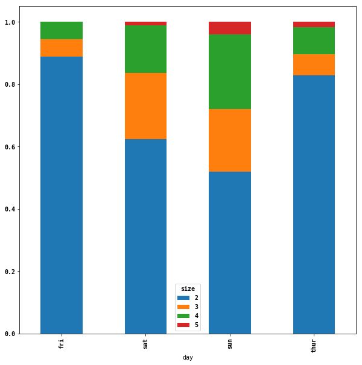

[figure not shown]

```python
party_pcts.plot(kind='bar',stacked=True)
plt.show()
```

## 3，直方图和密度图

直方图是一种对值频率进行离散化显示的柱状图。数据点被拆分到离散的，间隔均匀的面元中，绘制的是各面元中数据点的数量

```python
tips['tip_pct']=tips['tip']/tips['total_bill']
```

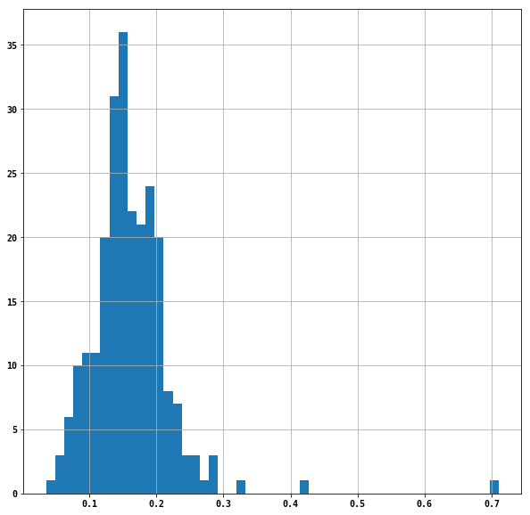

```python
tips['tip_pct'].hist(bins=50)
plt.show()
# y轴是个数，x轴是百分比
```

hist():画直方图,有许多参数

- x : (n,) array or sequence of (n,) arrays-----这个参数是指定每个bin(箱子)分布的数据,对应x轴
- bins : integer or array_like, optional------这个参数指定bin(箱子)的个数,也就是总共有几条条状图
- normed : boolean, optional------这个参数指定密度,也就是每个条状图的占比例比,默认为1
- color : color or array_like of colors or None, optional------这个指定条状图的颜色

密度图是通过计算“可能会产生观测数据的连续概率分布的估计”而产生的。一般是将该分布近似为一组核（如正态（高斯）分布）。因此也被称作KDE图。调用plot时加上kind=kde即可生成密度图（标准混合正态分布KDE）

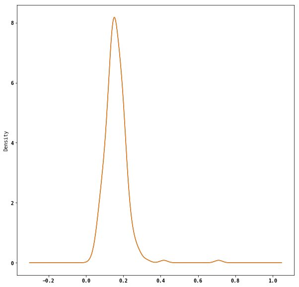

```python
tips['tip_pct'].plot(kind='kde')
plt.show()
```

```python
comp1=np.random.normal(0,1,size=200)  # N(0,1)
```

```python
comp2=np.random.normal(10,2,size=200)  # N(10,2)
```

```python
values=Series(np.concatenate([comp1,comp2]))
```

```python
values.hist(bins=100,alpha=0.3,color='m',normed=True)
```

```python
values.plot(kind='kde',style='k--')
```

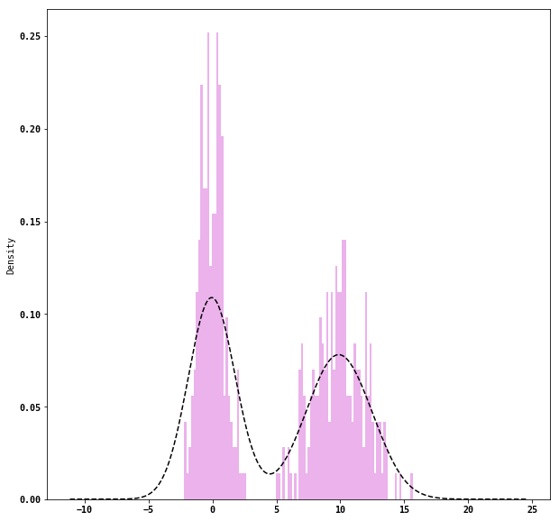

```python
plt.show()
```

## 4，散布图

散布图可观测两个一维数据序列之间的关系。matplotlib中的scatter是绘制散布图的主要方法。

```python
macro=pd.read_csv('D:/PythonDataAnalysis/ch08/macrodata.csv')
```

```python
data=macro[['cpi','m1','tbilrate','unemp']]
```

```python
trans_data=np.log(data).diff().dropna()
```

```python
trans_data[-5:]
```

|  | cpi | m1 | tbilrate | unemp |
| --- | --- | --- | --- | --- |
| 198 | -0.007904 | 0.045361 | -0.396881 | 0.105361 |
| 199 | -0.021979 | 0.066753 | -2.277267 | 0.139762 |
| 200 | 0.002340 | 0.010286 | 0.606136 | 0.160343 |
| 201 | 0.008419 | 0.037461 | -0.200671 | 0.127339 |
| 202 | 0.008894 | 0.012202 | -0.405465 | 0.042560 |

```python
plt.scatter(trans_data['m1'],trans_data['unemp'])
```

```python
plt.title('Changes in log %s vs. log %s' % ('m1','unemp'))
```

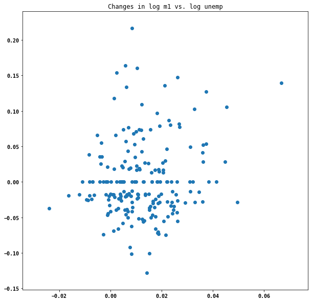

```python
plt.show()
```

一组散布图被称作散布矩阵，pandas提供了一个能从DataFrame创建散布图矩阵的scatter_matrix函数，它还支持在对角线上放置各变量的直方图或密度图

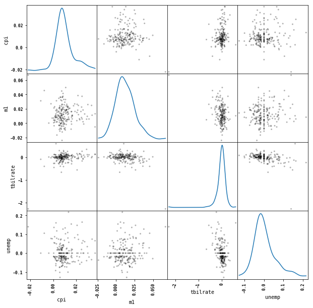

[figure not shown]

```python
pd.scatter_matrix(trans_data,diagonal='kde',color='k',alpha=0.3)
plt.show()
```